# EDA

This first cell is used to import the "Xicor" correlation coefficient function. The first link is where the original function code can be found. The second link is to the Stack Exchange post where I found out about Xicor, and the third link is an article describing the Xicor coefficient. The code itself is copy-pasted from the GitHub page in the first link.

```python
# https://gist.github.com/itamarfaran/0cffce51cd0e3d78ddf509b72a9e702d

# https://stats.stackexchange.com/questions/595101/methods-for-measuring-non-linear-correlation

# https://towardsdatascience.com/a-new-coefficient-of-correlation-64ae4f260310/


from typing import Literal, Tuple, Union

import numpy as np
import numpy.typing as npt
from scipy import stats


def xicor(
    x: npt.ArrayLike,
    y: npt.ArrayLike,
    ties: Union[bool, Literal["auto"]] = "auto",
) -> Tuple[float, float]:
    x = np.asarray(x).flatten()
    y = np.asarray(y).flatten()
    n = len(y)

    if len(x) != n:
        raise IndexError(f"x, y length mismatch: {len(x)}, {len(y)}")

    if ties == "auto":
        ties = len(np.unique(y)) < n
    elif not isinstance(ties, bool):
        raise ValueError(
            f'expected ties either "auto" or boolean, '
            f"got {ties} ({type(ties)}) instead"
        )

    y = y[np.argsort(x)]
    r = stats.rankdata(y, method="ordinal")
    nominator = np.sum(np.abs(np.diff(r)))

    if ties:
        l = stats.rankdata(y, method="max")
        denominator = 2 * np.sum(l * (n - l))
        nominator *= n
    else:
        denominator = np.power(n, 2) - 1
        nominator *= 3

    statistic = 1 - nominator / denominator  # upper bound is (n - 2) / (n + 1)
    p_value = stats.norm.sf(statistic, scale=2 / 5 / np.sqrt(n))

    return statistic
```

```python
# Import required libraries
import pandas as pd
import numpy as np
import seaborn as sns
import matplotlib.pyplot as plt

from sklearn.preprocessing import OrdinalEncoder
from sklearn.model_selection import train_test_split
from sklearn.ensemble import HistGradientBoostingRegressor

from sklearn.metrics import mean_absolute_error, mean_squared_error, median_absolute_error

%matplotlib inline
```

While the scripts use the kagglehub library, I cannot seem to get it to work in this notebook. As such, the following code is used instead, which simply downloads the data as a zip file with a csv file inside.

```python
# Download the data
!kaggle datasets download -d ahmedshahriarsakib/usa-real-estate-dataset
```

```
Dataset URL: https://www.kaggle.com/datasets/ahmedshahriarsakib/usa-real-estate-dataset
License(s): other
usa-real-estate-dataset.zip: Skipping, found more recently modified local copy (use --force to force download)
```

```python
# Load the data and check it out
df = pd.read_csv('realtor-data.zip.csv')
df.head()
```

|  | brokered_by | status | price | bed | bath | acre_lot | street | city | state | zip_code | house_size | prev_sold_date |
| --- | --- | --- | --- | --- | --- | --- | --- | --- | --- | --- | --- | --- |
| 0 | 103378.0 | for_sale | 105000.0 | 3.0 | 2.0 | 0.12 | 1962661.0 | Adjuntas | Puerto Rico | 601.0 | 920.0 | NaN |
| 1 | 52707.0 | for_sale | 80000.0 | 4.0 | 2.0 | 0.08 | 1902874.0 | Adjuntas | Puerto Rico | 601.0 | 1527.0 | NaN |
| 2 | 103379.0 | for_sale | 67000.0 | 2.0 | 1.0 | 0.15 | 1404990.0 | Juana Diaz | Puerto Rico | 795.0 | 748.0 | NaN |
| 3 | 31239.0 | for_sale | 145000.0 | 4.0 | 2.0 | 0.10 | 1947675.0 | Ponce | Puerto Rico | 731.0 | 1800.0 | NaN |
| 4 | 34632.0 | for_sale | 65000.0 | 6.0 | 2.0 | 0.05 | 331151.0 | Mayaguez | Puerto Rico | 680.0 | NaN | NaN |

```python
# Show dtypes, columns, and shape of data
df.info()
```

```
<class 'pandas.DataFrame'>
RangeIndex: 2226382 entries, 0 to 2226381
Data columns (total 12 columns):
 #   Column          Dtype
---  ------          -----
 0   brokered_by     float64
 1   status          str
 2   price           float64
 3   bed             float64
 4   bath            float64
 5   acre_lot        float64
 6   street          float64
 7   city            str
 8   state           str
 9   zip_code        float64
 10  house_size      float64
 11  prev_sold_date  str
dtypes: float64(8), str(4)
memory usage: 203.8 MB
```

It seems like this data takes up a lot of space. Also, the `.info()` method isn't showing null values here. Let's check those out next.

```python
# Show percentage of data that is null.
100 * df.isna().sum() / df.shape[0]
```

```
brokered_by        0.203604
status             0.000000
price              0.069215
bed               21.618797
bath              22.986666
acre_lot          14.624130
street             0.488056
city               0.063197
state              0.000359
zip_code           0.013430
house_size        25.533983
prev_sold_date    32.981627
dtype: float64
```

Quite a bit of missing data here. Luckily, my plan is to use a HistGradientBoostingRegressor, which can natively handle missing data, so there isn't really a need to do anything about that for the most part. The only issue is in the "price" column. Because this is the target variable, it cannot contain null values. Fortunately, less than 0.1% of the data has a missing price value, so dropping it won't lose much.

```python
# Drop null values in price column, repeat above cell
df = df.dropna(subset='price')
100 * df.isna().sum() / df.shape[0]
```

```
brokered_by        0.203745
status             0.000000
price              0.000000
bed               21.613275
bath              22.967574
acre_lot          14.614078
street             0.488305
city               0.063106
state              0.000360
zip_code           0.013394
house_size        25.524251
prev_sold_date    32.957681
dtype: float64
```

Next, I'll drop the columns I don't plan on using to train the model. These are `brokered_by`, `street`, and `prev_sold_date`. The first two are encoded, but I do not have access to the encoder. Because of this, users will not be able to pass these values into the model when they run it, and there is no point in training the model on variables users won't be able to predict on. The final column is the date the house was previously sold. This is a somewhat weird it of information for people to be looking at when comparing any product, so few people would likely even specify it. Also, nearly a third of the column is missing a value, so it makes sense to drop.

```python
# Drop unused columns
df = df.drop(columns=['prev_sold_date', 'brokered_by', 'street'])
```

```python
# Show data statistics
df.describe()
```

|  | price | bed | bath | acre_lot | zip_code | house_size |
| --- | --- | --- | --- | --- | --- | --- |
| count | 2.224841e+06 | 1.743980e+06 | 1.713849e+06 | 1.899701e+06 | 2.224543e+06 | 1.656967e+06 |
| mean | 5.241955e+05 | 3.275809e+00 | 2.496620e+00 | 1.521571e+01 | 5.218885e+04 | 2.714900e+03 |
| std | 2.138893e+06 | 1.567585e+00 | 1.652788e+00 | 7.630014e+02 | 2.895930e+04 | 8.083905e+05 |
| min | 0.000000e+00 | 1.000000e+00 | 1.000000e+00 | 0.000000e+00 | 0.000000e+00 | 4.000000e+00 |
| 25% | 1.650000e+05 | 3.000000e+00 | 2.000000e+00 | 1.500000e-01 | 2.961700e+04 | 1.300000e+03 |
| 50% | 3.250000e+05 | 3.000000e+00 | 2.000000e+00 | 2.600000e-01 | 4.841500e+04 | 1.760000e+03 |
| 75% | 5.500000e+05 | 4.000000e+00 | 3.000000e+00 | 9.800000e-01 | 7.807300e+04 | 2.413000e+03 |
| max | 2.147484e+09 | 4.730000e+02 | 8.300000e+02 | 1.000000e+05 | 9.999900e+04 | 1.040400e+09 |

Here, we can see that a few of the columns have some absurd values as their maximums. I mean, who needs 830 baths? That said, I'm only going to be removing outliers in the price column. This is mainly due to how robust HGB models are. Due to the binning process, or perhaps the underlying decision tree algorithm, HGB models tend to perform well even when the predictor variables contain outliers. however, I *do* want to reduce outliers in the target variable, both to reduce the range of values the models expects, and because some of these outliers have features similar to lower-priced houses, which could confuse the model.

For example, the following rows have fairly normal values for most of the data, with each of the features being less than or equal to the 75% value for that feature. Notably, these house listings, despite being relatively small to average, are priced at over 10,000,000 USD. Having rows that are outliers in price, but fall within normal ranges in the rest of the values could significantly lower model performance.

The value I have decided to use as the cutoff point for price is 1,000,000. This value is loosely based on being twice the 75% value. Also, most of the data falls below this value (a little over 90% of the data), so using this as the cutoff doesn't lose too much data.

```python
# Show rows with outlier price, but non-outlier other variables
df.query('price > 10000000 & bed <= 4 & bath <= 3 & acre_lot <= 1 & house_size <= 2413').sample(5)
```

|  | status | price | bed | bath | acre_lot | city | state | zip_code | house_size |
| --- | --- | --- | --- | --- | --- | --- | --- | --- | --- |
| 1270039 | for_sale | 1.300000e+07 | 4.0 | 3.0 | 0.08 | Manhattan Beach | California | 90266.0 | 2128.0 |
| 2076494 | sold | 1.125000e+07 | 2.0 | 3.0 | 0.11 | Malibu | California | 90265.0 | 1597.0 |
| 1363203 | for_sale | 1.100000e+07 | 2.0 | 2.0 | 0.55 | Kihei | Hawaii | 96753.0 | 976.0 |
| 1282590 | for_sale | 1.200000e+07 | 3.0 | 3.0 | 0.34 | Del Mar | California | 92014.0 | 1999.0 |
| 221994 | for_sale | 2.147484e+09 | 2.0 | 2.0 | 0.12 | International | California | NaN | 885.0 |

```python
# Show percentage of data with price above 1,000,000
100 * df.query('price < 1000000').shape[0] / df.shape[0]
```

```
91.29434418010096
```

```python
# Remove outliers in price, show statistics
df = df.query('price < 1000000')
df.describe()
```

|  | price | bed | bath | acre_lot | zip_code | house_size |
| --- | --- | --- | --- | --- | --- | --- |
| count | 2.031154e+06 | 1.578475e+06 | 1.550056e+06 | 1.735661e+06 | 2.030901e+06 | 1.499149e+06 |
| mean | 3.349259e+05 | 3.177730e+00 | 2.337912e+00 | 1.252825e+01 | 5.150007e+04 | 2.608899e+03 |
| std | 2.337199e+05 | 1.305011e+00 | 1.413464e+00 | 7.520701e+02 | 2.830307e+04 | 8.497988e+05 |
| min | 0.000000e+00 | 1.000000e+00 | 1.000000e+00 | 0.000000e+00 | 6.010000e+02 | 1.000000e+02 |
| 25% | 1.500000e+05 | 3.000000e+00 | 2.000000e+00 | 1.500000e-01 | 2.962500e+04 | 1.267000e+03 |
| 50% | 2.990000e+05 | 3.000000e+00 | 2.000000e+00 | 2.600000e-01 | 4.726500e+04 | 1.695000e+03 |
| 75% | 4.749000e+05 | 4.000000e+00 | 3.000000e+00 | 9.000000e-01 | 7.737700e+04 | 2.276000e+03 |
| max | 9.999990e+05 | 4.730000e+02 | 8.300000e+02 | 1.000000e+05 | 9.999900e+04 | 1.040400e+09 |

Next, I want to encode categorical columns so I can use them to train the model. For encoding, I have decided to use an ordinal encoder. I originally tried to one-hot encode the data, but one-hot encoding the `city` column raised an error with a message along the lines of "Cannot allocate 240 GiB of memory...", so if I want to keep the `city` column, I'd need to use a different method. Technically, as its name implies, ordinal encoding is meant for ordered data. Therefore, for the best results, the DataFrame will be ordered by the median price for each state. This way, the states will be ordinally encoded by there order in price, which should help model performance.

```python
# Create new column to store state medians
df['st_median'] = 0

# For each vlaue in state column, calculate median and add that value to every row with that state
for st in df['state'].unique():
    st_median = df.query(f'state == "{st}"').describe()['price']['50%']
    df.loc[df['state'] == st, 'st_median'] = st_median

# Sort dataset by state medians
df = df.sort_values(by='st_median', ignore_index=True)
df.head()
```

|  | status | price | bed | bath | acre_lot | city | state | zip_code | house_size | st_median |
| --- | --- | --- | --- | --- | --- | --- | --- | --- | --- | --- |
| 0 | for_sale | 7350.0 | NaN | NaN | 0.24 | Co | NaN | NaN | NaN | 0.0 |
| 1 | ready_to_build | 204990.0 | 3.0 | NaN | NaN | Binder | NaN | 96999.0 | 1273.0 | 0.0 |
| 2 | ready_to_build | 194990.0 | 3.0 | NaN | NaN | Binder | NaN | 96999.0 | 1443.0 | 0.0 |
| 3 | ready_to_build | 189990.0 | 3.0 | NaN | NaN | Binder | NaN | 96999.0 | 1273.0 | 0.0 |
| 4 | ready_to_build | 199990.0 | 3.0 | NaN | NaN | Binder | NaN | 96999.0 | 1546.0 | 0.0 |

Due to the specific way I have added the median for each state, any row without a `state` value gained a `st_median` value of 0. This shouldn't matter too much, as the model will likely just use other values to predict price when the `state` value is null. Next, we need to remove the `st_median` column. The only reason we added it was so that states with lower median prices get encoded with values closer together, and states with higher prices do the same. If we use this column to train the model, we could end up decreasing performance.

```python
# Remove state median column
df = df.drop(columns='st_median')
```

```python
# Specify categorical columns
cat_cols = ['city', 'state', 'status']

# Create and fit encoder to data
enc = OrdinalEncoder(encoded_missing_value=-1)
enc = enc.fit(df[cat_cols])

# Encode categorical columns
df[cat_cols] = enc.transform(df[cat_cols])
df.head()
```

|  | status | price | bed | bath | acre_lot | city | state | zip_code | house_size |
| --- | --- | --- | --- | --- | --- | --- | --- | --- | --- |
| 0 | 0.0 | 7350.0 | NaN | NaN | 0.24 | 3422.0 | -1.0 | NaN | NaN |
| 1 | 1.0 | 204990.0 | 3.0 | NaN | NaN | 1472.0 | -1.0 | 96999.0 | 1273.0 |
| 2 | 1.0 | 194990.0 | 3.0 | NaN | NaN | 1472.0 | -1.0 | 96999.0 | 1443.0 |
| 3 | 1.0 | 189990.0 | 3.0 | NaN | NaN | 1472.0 | -1.0 | 96999.0 | 1273.0 |
| 4 | 1.0 | 199990.0 | 3.0 | NaN | NaN | 1472.0 | -1.0 | 96999.0 | 1546.0 |

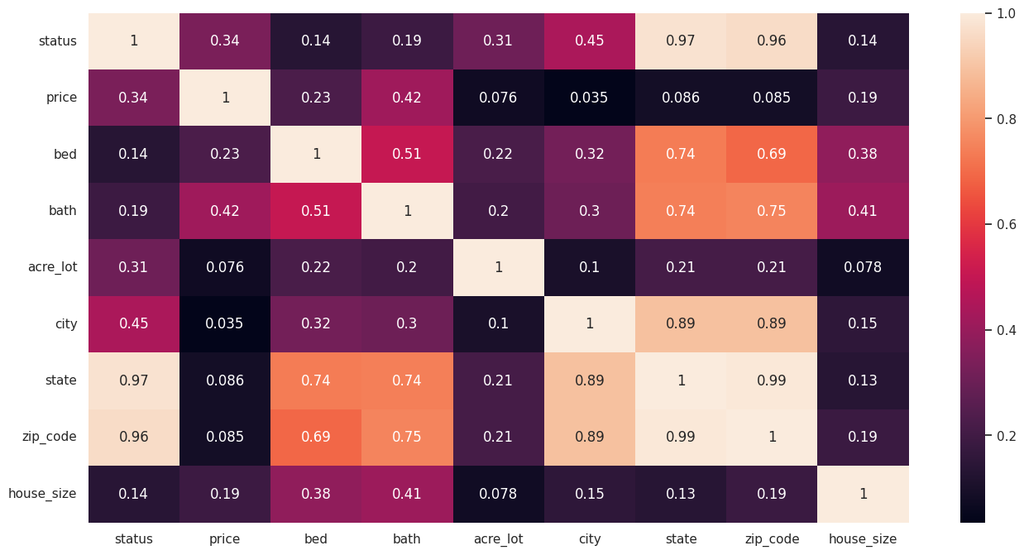

```python
# Set size of correlation heatmap
sns.set(rc={'figure.figsize':(16, 8)})

# Use Xicor coefficient to plot correlation heatmap
sns.heatmap(df.corr(method=xicor), annot=True)
```

Well, I was hoping that by ordering the dataset by median state price would show a higher correlation between `state` and `price`. Let's check what the data actually looks like. Even if the math can't see a strong correlation, human eyes surely can!

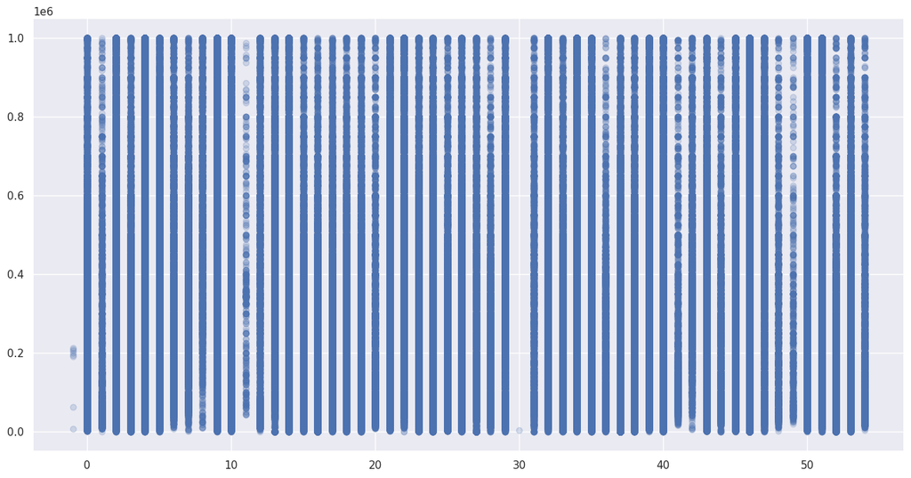

```python
# Plot state vs price scatter plot
plt.scatter(df['state'], df['price'], alpha=0.2);
```

Oh.

In retrospect, this should have been obvious. The median value may change quite a lot between states, but the range of values is mostly the same, especially considering I specified an upper limit, and different median values doesn't necessarily mean the mode or distribution of values are significantly different. Oh, well. maybe it'll still improve model performance. Speaking of, it's about time I get started on the actual model.

```python
# Split data into training and testing sets
X_train, X_test = train_test_split(df, random_state=42)

# Remove price for datasets and create target (y) arrays
y_train = X_train.pop('price')
y_test = X_test.pop('price')
```

```python
# Instantiate reggressor with otpimized hyperparams and fit to training dataset
regressor = HistGradientBoostingRegressor(
    loss='absolute_error',
    random_state=42,
    learning_rate=0.4,
    max_iter=550,
    max_leaf_nodes=125,
    min_samples_leaf=75,
    max_depth=75
)
model = regressor.fit(X_train, y_train)
```

```python
# Create predictions on test set
preds = model.predict(X_test)

# Compute and print metrics: Median abs error, Mean abs error, R squared
mdae = round(median_absolute_error(y_test, preds), 2)
mae = round(mean_absolute_error(y_test, preds), 2)
r2 = round(model.score(X_test, y_test), 4)

print(f'Mean absolute error: {mae}')
print(f'Median absolute error: {mdae}')
print(f'R_2 score: {r2}')
```

```
Mean absolute error: 74745.98
Median absolute error: 44765.0
R_2 score: 0.7426
```

The final thing to do is to create a csv file to use in Tableau to create a visualization of the error metrics. This is done in the following cell. First, a variable called `vis_df` is created, which is just the `X_test` variable from earlier. Next, 5 new columns are added to the DataFrame. These columns are the predicted price, the predicted price + and - the median absolute error, and the predicted price + and - the mean absolute error. Finally, the true price for each row, `y_test` is added, and the categorical columns are un-encoded.

```python
# Specify dataset to visualize; if, for example, I realize I've used the wrong dataset, I only have to change this first line
vis_df = X_test

# Predict prices and add predictions and ranges to df
vis_preds = model.predict(vis_df)
vis_df['predicted_price'] = np.around(vis_preds, decimals=2)
vis_df['min_estimate_median'] = np.around(vis_df['predicted_price'] - mdae, decimals=2)
vis_df['max_estimate_median'] = np.around(vis_df['predicted_price'] + mdae, decimals=2)
vis_df['min_estimate_mean'] = np.around(vis_df['predicted_price'] - mae, decimals=2)
vis_df['max_estimate_mean'] = np.around(vis_df['predicted_price'] + mae, decimals=2)

# Add true prices to df to compare
vis_df['true_price'] = y_test

# enc_cols = enc.get_feature_names_out()
vis_df[cat_cols] = enc.inverse_transform(vis_df[cat_cols])

# Remove columns that will not be used in visualizations
vis_df = vis_df.drop(columns=['city', 'status'])
vis_df.head()
```

|  | bed | bath | acre_lot | state | zip_code | house_size | predicted_price | min_estimate_median | max_estimate_median | min_estimate_mean | max_estimate_mean | true_price |
| --- | --- | --- | --- | --- | --- | --- | --- | --- | --- | --- | --- | --- |
| 35222 | 4.0 | 3.0 | 2.00 | West Virginia | 25425.0 | 2504.0 | 384010.30 | 339245.30 | 428775.30 | 309264.32 | 458756.28 | 249000.0 |
| 1542654 | NaN | NaN | 1.03 | Maryland | 21742.0 | NaN | 82538.46 | 37773.46 | 127303.46 | 7792.48 | 157284.44 | 83500.0 |
| 1383311 | 4.0 | 3.0 | 0.16 | Texas | 76542.0 | 2656.0 | 310761.85 | 265996.85 | 355526.85 | 236015.87 | 385507.83 | 318000.0 |
| 1311571 | NaN | NaN | 26.60 | Texas | 75644.0 | NaN | 234576.82 | 189811.82 | 279341.82 | 159830.84 | 309322.80 | 225000.0 |
| 1642505 | 3.0 | 4.0 | 1.00 | New Jersey | 8062.0 | 1465.0 | 355141.02 | 310376.02 | 399906.02 | 280395.04 | 429887.00 | 415000.0 |

```python
# Write vis_df to csv file
vis_df.to_csv('vis_df.csv', index=False)
```

A couple of things to note here. First, I actually trained the model the same way without ordering the data, and after comparing the metrics, there is not a significant difference. Because of this, the "train_model.py" script located in the GitHub repo does not order the data before training. Second, the grid search is not here. I performed a grid search to find the above hyperparameters, using a pc with higher specs than the laptop used for the rest of this project. Unfortuneately, I forgot to save that notebook before closing the window, so the actual cell that ran the grid search no longer has any output.

The following cells have the code that ran the grid search, but not the output. The final metrics can be seen above, but the time it took to run cannot, so I'll say it here. The first grid seach took about 63 hours, and the second took about 10 hours, for a total of about 73 hours, or three days.

```python
from sklearn.model_selection import GridSearchCV
from time import time


def search(parameters, X_train, y_train, X_test, y_test):
    """
    Performs a grid search on a HistGradientBoostingRegressor, using split data.

    ACCEPTS:
        parameters - dict of hyperparams to seach over
        X_train - training data sans target variable
        y_train - training data target variable
        X_test - testing data sans target variable
        y_test - testing data target variable

    RETURNS:
        best_model - Optimized model based on mean_absolute_error
    """
    # Instantiate regressor
    reg = HistGradientBoostingRegressor(loss='absolute_error', random_state=42)

    # Start timer
    start = time()

    # Search over parameters, trying to minimize mean_absolute_error
    grid_obj = GridSearchCV(reg, parameters, scoring='neg_mean_absolute_error')
    grid_fit = grid_obj.fit(X_train, y_train)

    # End timer, print time taken to search
    end = time()
    print(f'{round(end-start, 4)} seconds OR\n{round((end-start)/60, 4)} minutes OR\n{round((end-start)/(60*60), 4)} hours\n')

    # Select best model
    best_model = grid_fit.best_estimator_

    # Train unoptimized model and compare
    model = reg.fit(X_train, y_train)
    preds = model.predict(X_test)
    best_preds = best_model.predict(X_test)

    print('Unoptimized Model\n-----------')
    print(f'Mean absolute error on testing data: {round(mean_absolute_error(y_test, preds), 2)}')
    print(f'Median absolute error on testing data: {round(median_absolute_error(y_test, preds), 2)}')
    print(f'R squared score: {round(model.score(X_test, y_test), 4)}')

    print('Optimized Model\n-----------')
    print(f'Mean absolute error on testing data: {round(mean_absolute_error(y_test, best_preds), 2)}')
    print(f'Median absolute error on testing data: {round(median_absolute_error(y_test, best_preds), 2)}')
    print(f'R squared score: {round(best_model.score(X_test, y_test), 4)}')

    return best_model
```

Using the above function, a search was performed on a primary set of parameters, labeled below as `prim_parameters`. With the hyperparameter values in the returned `best_model`, a secondary search was performed, where each hyperparameter used the values from the optimized model, as well as new values that were all slighlty off of the optimized value, in order to further tune the model. These parameters are labeled `sec_parameters`.

```python
prim_parameters = {
    'learning_rate': [0.01, 0.05, 0.1, 0.5, 1],
    'max_iter': [10, 50, 100, 200, 500],
    'max_leaf_nodes': [10, 30, 50, 100],
    'min_samples_leaf': [2, 5, 10, 50, 100],
    'max_depth': [2, 5, 10, 100, 200, None]
}

sec_parameters = {
    'learning_rate': [0.4, 0.5, 0.6],
    'max_iter': [450, 500, 550],
    'max_leaf_nodes': [75, 100, 125],
    'min_samples_leaf': [75, 100, 125],
    'max_depth': [75, 100, 125]
}
```